# Series Temporales

# 12 Example: Temperature forecast in Malaga - Exponential Smoothing

We obtain a time-series object with the `ts` function. data are divided into months, the parameter *frequency* is set to 12 and we indicate that we start in January 2001. After this, we draw the object:

```r
library('ggplot2')
library('TTR')
library('forecast')
library('tseries')
```

```r
library(readr)
temperaturas <- read_csv("./temp.csv")
```

```r
ts.p1 <- ts(temperaturas$tm_min, start = c(2001, 1), frequency = 12)
plot.ts(ts.p1, xlab = "años", ylab = "temperatura mínima", main = "Temperaturas mínimas Málaga")
```

[output not shown]

**Forecasts using Exponential Smoothing**

*Exponential Smoothing* considers weights on variable values: weighted averages of past observations. The weights decrease exponentially for distant values.

## 12.1 Simple Exponential Smoothing

- alpha parameter of Holt-Winters Filter.
- beta parameter of Holt-Winters Filter. If set to FALSE, the function will do exponential smoothing.
- gamma parameter used for the seasonal component. If set to FALSE, an non-seasonal model is fitted.

Looking at these parameters we have to assemble a model with *beta=FALSE* as we want exponential smoothing.

```r
# we obtain the model
ts.p1.forecasts <- HoltWinters(ts.p1, beta = FALSE)
ts.p1.forecasts
## Holt-Winters exponential smoothing without trend and with additive seasonal component.
##
## Call:
## HoltWinters(x = ts.p1, beta = FALSE)
##
## Smoothing parameters:
##  alpha: 0.1412013
##  beta : FALSE
##  gamma: 0.2045694
##
## Coefficients:
##           [,1]
## a   14.8002193
## s1  -3.0179721
## s2  -5.3483612
## s3  -6.0676567
## s4  -5.8300885
## s5  -4.2971166
## s6  -2.0597869
## s7   0.5443399
## s8   4.3512303
## s9   6.9081866
## s10  7.9327353
## s11  5.3361482
## s12  1.4610327
```

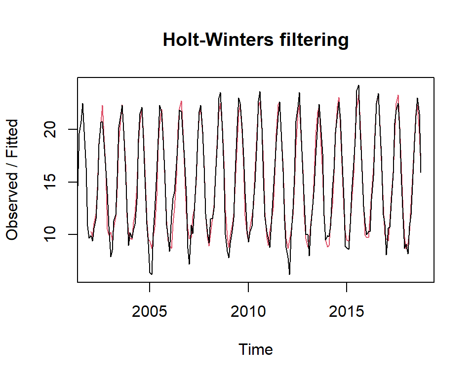

```r
# we draw the model
plot(ts.p1.forecasts)
```

The graph shows the original time series in black, and forecasts of these values as a red line. The forecast time series is very close to the original data.

We now draw the forecast using `forecast`.

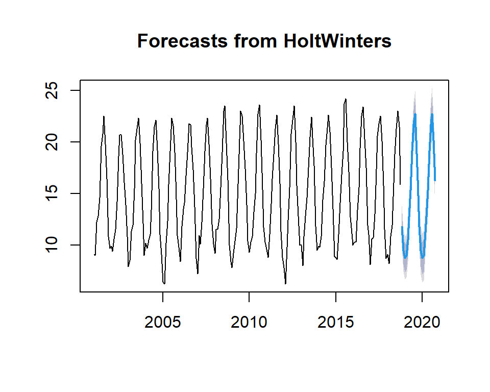

```r
plot(forecast(ts.p1.forecasts))
```

As we can see it fits quite well with what is happening in recent years.

Let’s try a higher *alpha* value:

```r
ts.p2.forecasts <- HoltWinters(ts.p1, alpha = 0.5, beta = FALSE)
ts.p2.forecasts
## Holt-Winters exponential smoothing without trend and with additive seasonal component.
##
## Call:
## HoltWinters(x = ts.p1, alpha = 0.5, beta = FALSE)
##
## Smoothing parameters:
##  alpha: 0.5
##  beta : FALSE
##  gamma: 0.3927417
##
## Coefficients:
##           [,1]
## a   15.0512589
## s1  -3.1697282
## s2  -5.4838631
## s3  -6.2075694
## s4  -5.9219038
## s5  -4.2667725
## s6  -1.8548302
## s7   0.8149946
## s8   4.5957651
## s9   7.0279317
## s10  8.0279557
## s11  5.3161216
## s12  1.1929326
```

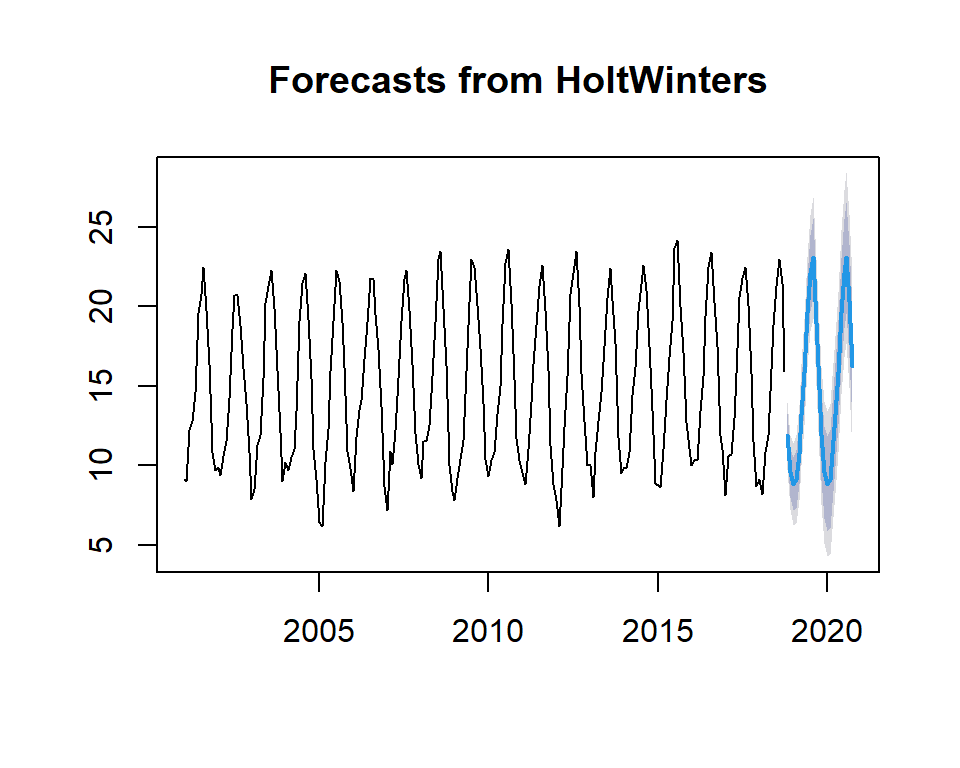

```r
plot(forecast(ts.p2.forecasts))
```

```r
ts.p3.forecasts <- HoltWinters(ts.p1, alpha = 0.9, beta = FALSE)
ts.p3.forecasts
## Holt-Winters exponential smoothing without trend and with additive seasonal component.
##
## Call:
## HoltWinters(x = ts.p1, alpha = 0.9, beta = FALSE)
##
## Smoothing parameters:
##  alpha: 0.9
##  beta : FALSE
##  gamma: 0.9999496
##
## Coefficients:
##           [,1]
## a   14.7654331
## s1  -3.0613814
## s2  -5.3688209
## s3  -5.8712039
## s4  -5.2291009
## s5  -3.4451379
## s6  -1.4794315
## s7   0.5904564
## s8   4.0760361
## s9   6.5257969
## s10  7.4170932
## s11  4.6994542
## s12  1.1345783
```

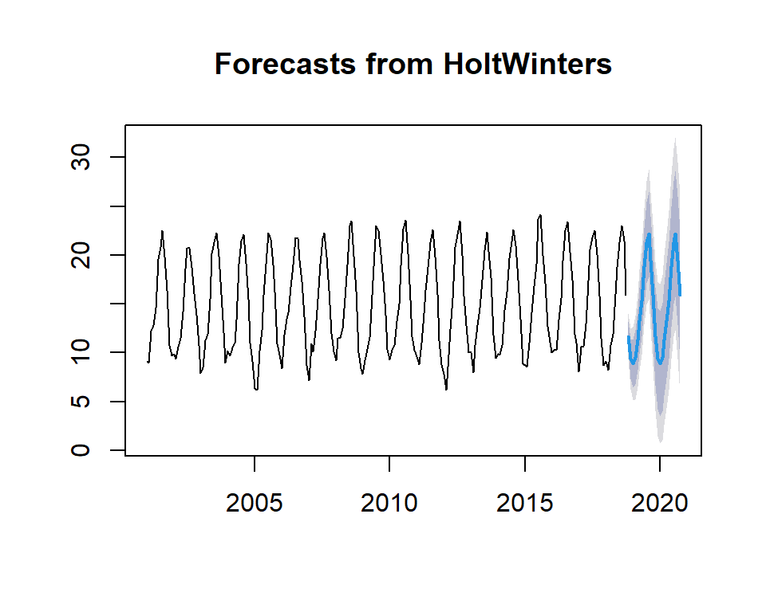

```r
plot(forecast(ts.p3.forecasts))
```

## 12.2 Forecasting using forecast package

When we use the *`forecast.HoltWinters`* function, as the first argument, it is passed the predictive model that we have already set using the `HoltWinters` function.

To specify how many additional time points we want to predict, we use the parameter *“h”*.

The prediction for the next 2 years is:

```r
# we indicate the parameter h=24 for 2 years, as we have the time series by months
ts.p1.forecasts2 <- forecast:::forecast.HoltWinters(ts.p1.forecasts, h = 24)
ts.p1.forecasts2
```

```
##          Point Forecast     Lo 80    Hi 80     Lo 95    Hi 95
## Nov 2018      11.782247 10.448881 13.11561  9.743039 13.82146
## Dec 2018       9.451858  8.105265 10.79845  7.392421 11.51129
## Jan 2019       8.732563  7.372871 10.09225  6.653094 10.81203
## Feb 2019       8.970131  7.597467 10.34279  6.870822 11.06944
## Mar 2019      10.503103  9.117587 11.88862  8.384139 12.62207
## Apr 2019      12.740432 11.342183 14.13868 10.601995 14.87887
## May 2019      15.344559 13.933692 16.75543 13.186823 17.50229
## Jun 2019      19.151450 17.728075 20.57482 16.974587 21.32831
## Jul 2019      21.708406 20.272634 23.14418 19.512582 23.90423
## Aug 2019      22.732955 21.284891 24.18102 20.518333 24.94758
## Sep 2019      20.136368 18.676116 21.59662 17.903106 22.36963
## Oct 2019      16.261252 14.788913 17.73359 14.009504 18.51300
## Nov 2019      11.782247 10.250481 13.31401  9.439613 14.12488
## Dec 2019       9.451858  7.908565 10.99515  7.091594 11.81212
## Jan 2020       8.732563  7.177827 10.28730  6.354800 11.11032
## Feb 2020       8.970131  7.404038 10.53622  6.574998 11.36526
## Mar 2020      10.503103  8.925733 12.08047  8.090724 12.91548
## Apr 2020      12.740432 11.151866 14.32900 10.310930 15.16993
## May 2020      15.344559 13.744875 16.94424 12.898054 17.79106
## Jun 2020      19.151450 17.540725 20.76217 16.688058 21.61484
## Jul 2020      21.708406 20.086715 23.33010 19.228243 24.18857
## Aug 2020      22.732955 21.100371 24.36554 20.236134 25.22978
## Sep 2020      20.136368 18.492964 21.77977 17.622999 22.64974
## Oct 2020      16.261252 14.607099 17.91541 13.731443 18.79106
```

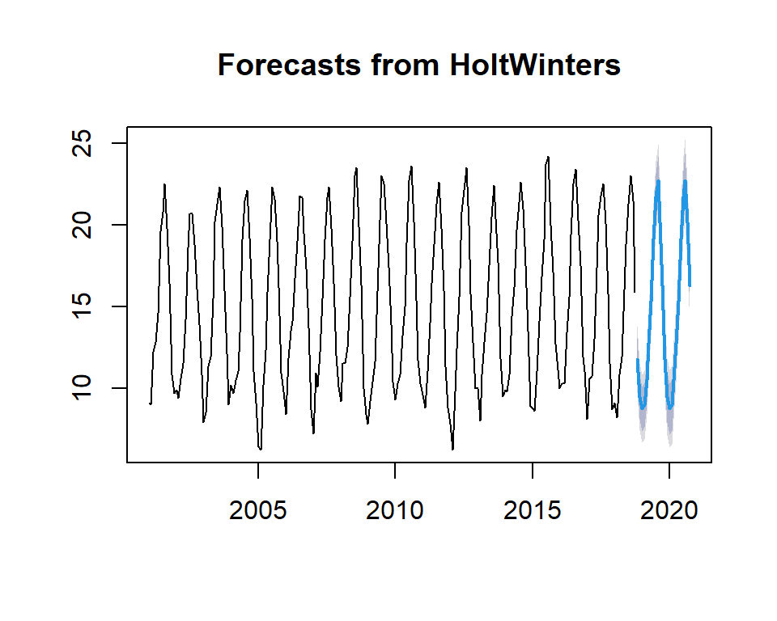

```r
forecast:::plot.forecast(ts.p1.forecasts2)
```

The forecasts for the next 2 years are represented as a blue line, the 80% prediction interval as a dark grey shaded area and the 95% prediction interval as a grey shaded area.

**Forecast errors**

Errors are stored in `residuals`.

- If the model cannot be improved, there should be no correlations between forecast errors for successive predictions.
- If there are correlations between forecast errors for successive predictions, it is likely that the predictions can be improved with another technique.

To find out which is the case, we can obtain a correlation of the errors. We can calculate it using the `acf` function. `acf` calculates the estimate of the autocovariance or autocorrelation function *(ACF)*.

Let’s see what happens, we use `acf` with residuals and lag max 24.

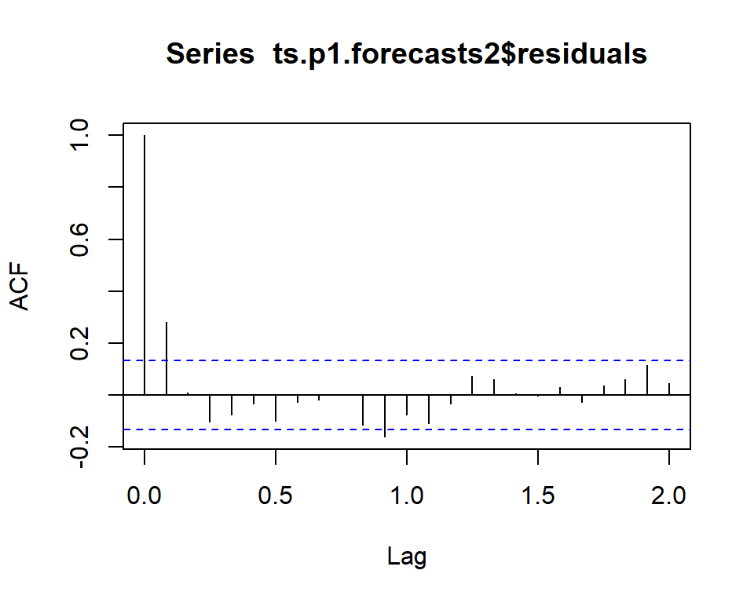

```r
# na.action, to take or not to take into account the NA values
acf(ts.p1.forecasts2$residuals, na.action = na.pass, lag.max = 24)
```

We performed a Ljung Box text to see if there is significant evidence of non-zero correlations in the **lag**.

```r
Box.test(ts.p1.forecasts2$residuals, lag = 24, type = "Ljung-Box")
```

```
##
##  Box-Ljung test
##
## data:  ts.p1.forecasts2$residuals
## X-squared = 41.723, df = 24, p-value = 0.01386
```

As we can see, the p-value is 0.01, which tells us that there is evidence of autocorrelations other than 0.

Note: The ACF (AutoCorrelation Function) chart is used to identify non-stationary time series. Stationary: if the ACF is rapidly declining

# 13 ARIMA methods

The difference between exponential smoothing models and ARIMA models is that the former are based on a description of the trend and seasonality of the data, while **ARIMA models study the autocorrelations of the data.**

As we have already seen, the name ARIMA comes from *AutoRegressive Integrated Moving Average*.

- *AR*: the study variable is analysed using the above values (*lag*).
- **MA**: the regression error is a linear combination of current and past values of the signal.
- *I*: replaces the value of the variable by the difference between the values and the previous values (one or more times).

ARIMA models can be obtained following the **Box-Jenkins** method.

### 13.0.1 Stationarity

A time series is said to be stationary when it does not depend on the instant of observation (white noise series).

The autocovariance function is defined as
$$Cov(y_t,y_{t+k}) = \gamma(k), \forall k$$

That is, the covariance does not depend on time, only on the parameter $k$ (lag).

- If a series has a trend or stationarity it is not stationary.
- A time series that has a cyclical component is stationary.

## 13.1 Autoregressive models - **AR(p)**

The current value of the $x_t$ series can be explained as a function of $p$ past values, $x_{t-1},x_{t-2},x_{t-p}$, where $p$ determines the number of past steps needed for the prediction.

$$y_t=c+\phi_1y_{t-1}+\phi_2y_{t-2}+\cdots+\phi_py_{t-p}+\epsilon_t$$

- $\epsilon_t$: Gaussian white noise with mean 0 and variance $sigma^2_epsilon$.
- If the mean is non-zero, $c$ takes the value $c = \mu(1-\phi_1-\cdots-\phi_p)$.

This is an autoregressive model of order $p$ that applies to stationary models.

## 13.2 Moving average models

As an alternative to the autoregressive representation where $x_t$ (on the left-hand side of the equation) are assumed to be linear combinations using moving averages of order $q$, $MA(q)$. We assume white noise $epsilon_t$. Model MA($q$):

$$y_t=c+\epsilon_t+\theta_1\epsilon_{t-1}+\theta_2\epsilon_{t-2}+\cdots+\theta_q\epsilon_{t-q}$$

As with autoregressive models, changing the parameters affects the time series patterns and changing the error term changes the scale.

### 13.2.1 Differentiation

To convert a non-stationary time series into a stationary time series, the differences between consecutive signal values are calculated (trend and seasonality are removed or reduced).

The following equation allows to calculate the differences between consecutive signal values:

$$y'_t=y_t-y_{t-1}$$

If the differentiated series is white noise:

$$y_t-y_{t-1}=\epsilon_t$$
($\epsilon_t$ denotes white noise)

A closely related model allows the difference to have a non-zero mean.
$$y_t-y_{t-1}=c+\epsilon_t$$
where $c$ is the average of the changes between consecutive observations.

### 13.2.2 Second order differencing

The difference of the data may have to be recalculated a second time to obtain a stationary series (the change in changes).

### 13.2.3 Seasonal differencing

```r
lynx <- read.csv(file = "annual-number-of-lynx-trapped-ma.csv", header = TRUE, quote = '\"')
lynx.ts <- ts(lynx$Lynx, frequency = 1, start = c(1821))
electricity <- read.csv(file = "monthly-electricity-production-i.csv", header = TRUE, quote = '\"')
electricity.ts <- ts(electricity$Million.kilowatt.hours, frequency = 12, start = c(1956, 1))
```

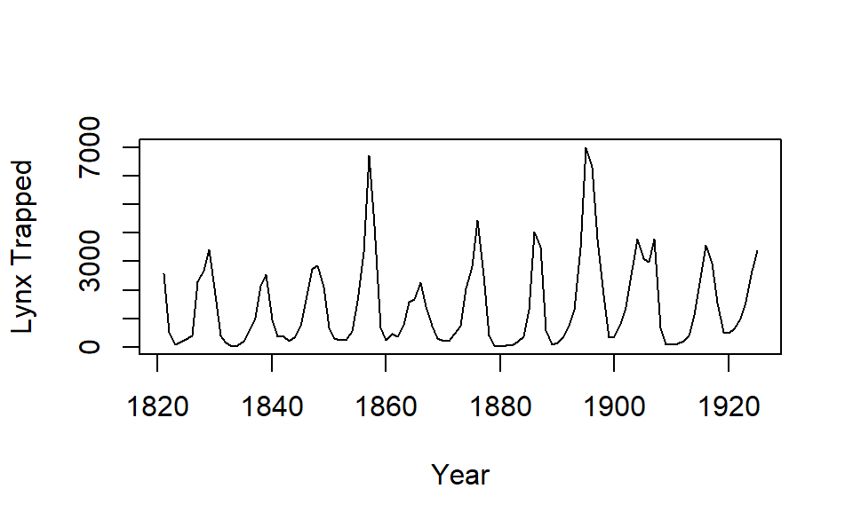

Figure 13.1: Although there are cycles, they are not fixed in time.

```r
plot.ts(lynx.ts, xlab = "Year", ylab = "Lynx Trapped")
```

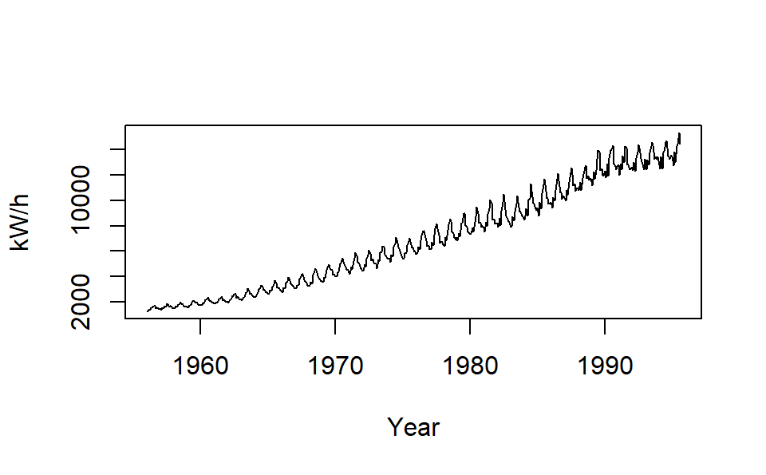

Figure 13.2: Clear trend indicates this is not a stationary series.

```r
plot.ts(electricity.ts, xlab = "Year", ylab = "kW/h")
```

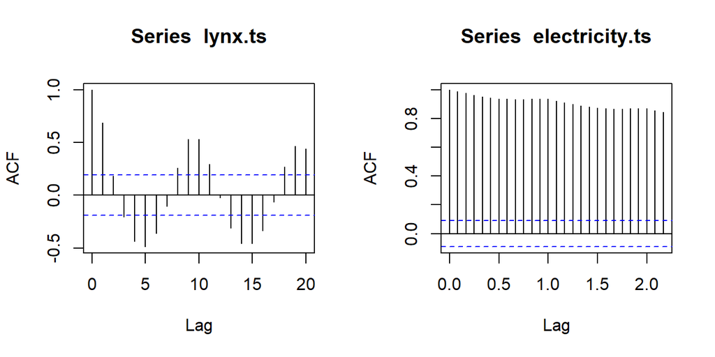

Figure 13.3: Lynx trapped ACF plot (left) and kilowatts per hour in Australia ACF plot (right).

```r
par(mfrow = c(1, 2))
acf(lynx.ts)
acf(electricity.ts)
```

## 13.3 Parameters in ARIMA methods.

Therefore, in an ARIMA model we will use three parameters: (*p*, *d*, *q*).

- **p**: refers to the use of past values of the series. It specifies the number of lags used in the model. For example, AR(2) or, ARIMA(2,0,0) specifies the use of two lags of the series.
- **d**: degree of differentiation. Differencing your current and previous values *d* times.
- **q**: model error as a combination of q previous error terms.

ARIMA works best for long and stable series.

## 13.4 Non-seasonal ARIMA models

If we combine differencing and autoregression we obtain a non-seasonal ARIMA model:
$$y'_t = c + \phi_1y'_{t-1}+\cdots+\phi_py'_{t-p}+\theta_1\epsilon_{t-1}+\cdots+\theta_q\epsilon_{t-q}+\epsilon_t$$
where $y'_t$ is the series to which differencing has been applied. These models are represented as ARIMA($p,d,q$), where $d$ represents the degree of differencing.

## 13.5 Auto-ARIMA model

In R we have functions that automatically calculate the parameter values of an ARIMA model.

The *`auto.arima()`* function is a modification of the **Hyndman-Khandakar** algorithm.

R’s `auto.arima()` function combines tests, and minimisations to obtain an ARIMA model. By default, it can use initial approximations to speed up the model search (`approximation=TRUE/FALSE`).

To choose a custom model for a non-seasonal series, we will use the `Arima()` function as follows:

1. Draw the dataset and identify outliers.
2. Transform the data to stabilise the variance.
3. If the data is not stationary use differencing until it is.
4. Analyse ACF/PACF for an ARIMA($p,d,0$) or ARIMA($0,d,q$) model.
5. Try to pick your model and use AICc to find the best one.
6. Check that the residuals behave like white noise:
- if this is not satisfied look for another model
- if this is true, we can use the model to predict

# 14 Example: Temperature forecast in Malaga - Modelos ARIMA

Analyse the evolution of the minimum temperatures since 2001 in Malaga **with the methods seen in this document**.

We obtain a time-series object with the `ts` function, as our data are divided into months, we set the parameter *frequency* to 12 and we indicate that we start in January 2001. Then we draw the object obtained:

```r
library('ggplot2')
library('TTR')
library('forecast')
library('tseries')
```

```r
library(readr)
temperaturas <- read_csv("./temp.csv")
```

```r
ts.p1 <- ts(temperaturas$tm_min, start = c(2001, 1), frequency = 12)
plot.ts(ts.p1, xlab = "años", ylab = "temperatura mínima", main = "Temperaturas mínimas Málaga")
```

[output not shown]

*ARIMA models*

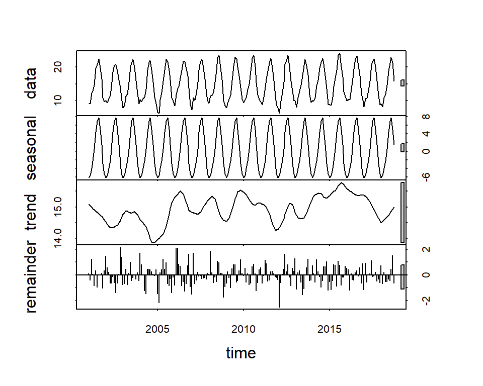

```r
# we obtain a time series with a frequency of 12 months
obj.ts <- ts(na.omit(temperaturas$tm_min), frequency = 12, start = c(2001, 1))

# descompose
decomp <- stl(obj.ts, s.window = "periodic") # uses additive model by default
# decomposing the series and removing the seasonality can be done with seasadj() within the forecast package
deseasonal_cnt <- seasadj(decomp)
plot(decomp)
```

```r
# with ADF test we can know if it is stationary or not.
adf.test(obj.ts, alternative = "stationary")
```

[output not shown]

We fix an ARIMA model using auto.arima:

```r
fit <- auto.arima(deseasonal_cnt, seasonal = FALSE)
fit
## Series: deseasonal_cnt
## ARIMA(1,1,1)
##
## Coefficients:
##          ar1      ma1
##       0.3684  -0.9799
## s.e.  0.0668   0.0175
##
## sigma^2 = 0.7702:  log likelihood = -274.66
## AIC=555.32   AICc=555.44   BIC=565.41
```

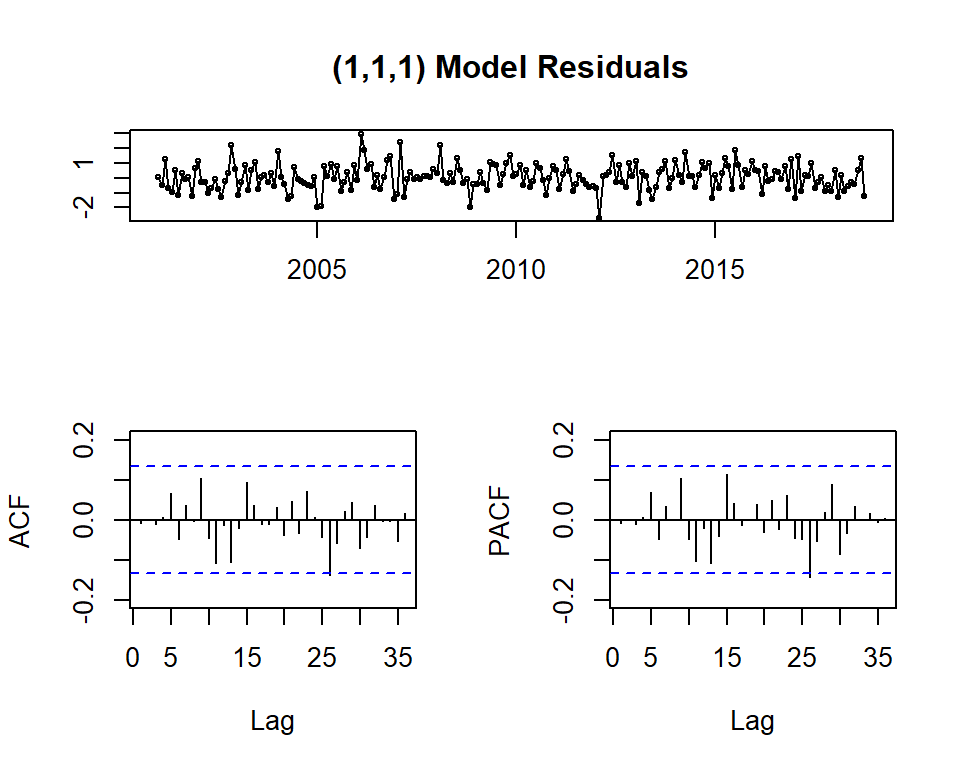

```r
tsdisplay(residuals(fit), main = "(1,1,1) Model Residuals")
```

```r
fit2 <- arima(deseasonal_cnt, order = c(1, 1, 23))

fit2
```

```
##
## Call:
## arima(x = deseasonal_cnt, order = c(1, 1, 23))
##
## Coefficients:
##           ar1     ma1      ma2      ma3      ma4     ma5      ma6      ma7
##       -0.7624  0.1627  -0.6937  -0.1923  -0.0753  0.0409  -0.1322  -0.0994
## s.e.   0.2475  0.2564   0.1611   0.1147   0.0880  0.0930   0.1067   0.1014
##          ma8     ma9    ma10     ma11     ma12     ma13    ma14    ma15    ma16
##       0.0485  0.2009  0.0295  -0.2316  -0.1224  -0.1786  0.0240  0.3970  0.1431
## s.e.  0.0936  0.0982  0.0963   0.1006   0.0939   0.0922  0.0978  0.1027  0.1168
##          ma17     ma18    ma19    ma20    ma21     ma22     ma23
##       -0.1927  -0.2143  0.0691  0.1088  0.1423  -0.0907  -0.0931
## s.e.   0.0902   0.1099  0.0969  0.1216  0.1053   0.1051   0.1117
##
## sigma^2 estimated as 0.6437:  log likelihood = -261.09,  aic = 572.19
```

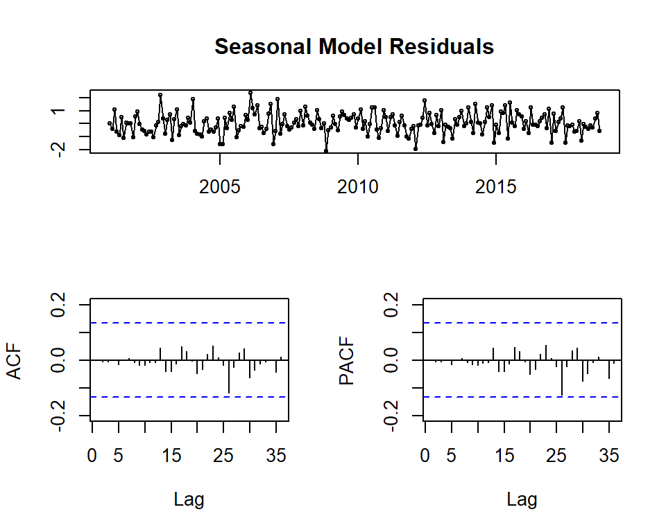

```r
tsdisplay(residuals(fit2), main = "Seasonal Model Residuals")
```

We forecast for the next 30 months:

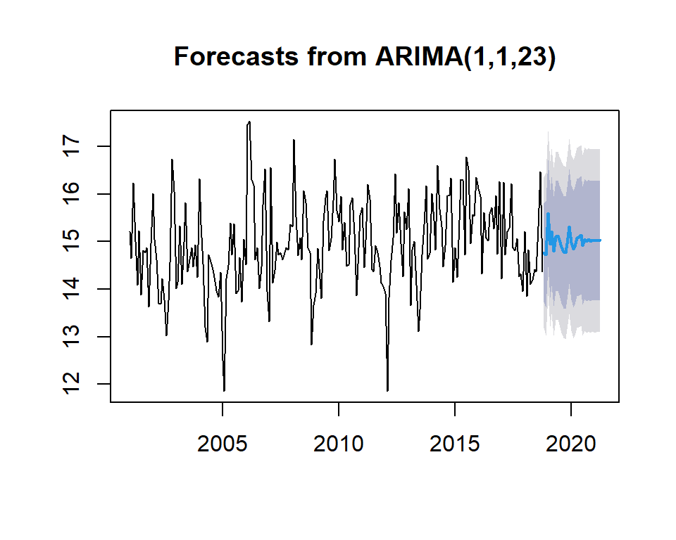

```r
fcast <- forecast(fit2, h = 30)
plot(fcast)
```

# 15 References

Information and images obtained from:

[Forecasting: Principles and Practice. Rob J Hyndman and George Athanasopoulos. Monash University, Australia](https://otexts.org/fpp2/)

[Introducion to Forecasting with ARIMA in R](https://www.datascience.com/blog/introduction-to-forecasting-with-arima-in-r-learn-data-science-tutorials)

AEMET